# Text prediction via N-gram Stupid Back-off models

Valerio Gherardi

vgherard@sissa.it

2020-12-05

## Introduction

The `sbo` package provides utilities for building and evaluating next-word prediction functions based on [Stupid Back-off](https://www.aclweb.org/anthology/D07-1090.pdf) N-gram models in R. In this vignette, I illustrate the main features of `sbo`, including in particular:

- the typical workflow for building a text predictor from a given training corpus, and
- the evaluation of next-word predictions through a test corpus.

```r
library(sbo)
```

## Building text predictors with `sbo`

### Building a text predictor

In this and the next section we will employ the `sbo::twitter_train` example dataset[[^1]](https://cran.r-project.org/web/packages/sbo/vignettes/sbo.html#fn1), each entry of which consists in a single tweet in English, *e.g.*:

```r
head(sbo::twitter_train, 3)
```

```
#> [1] "FOX NEWS TODAY: \"Energizer Bunny Arrested, Charged With Battery!\""
#> [2] "Today is a good day! Excluding today, I only have 9 days of class left. Awww yeaaahh"
#> [3] "I will be at broadway bar tonight"
```

Given the training corpus, the typical workflow for building a text-predictor consists of the following steps:

1. *Preprocessing*. Apply some transformations to the training corpus before $k$-gram extraction.
2. *Sentence tokenization*. Split the training corpus into sentences.
3. *Extract $k$-gram frequencies*. These are the building blocks for any $N$-gram language model.
4. *Train a text predictor*. Build a prediction function $f$, which takes some text input and returns as output a next-word prediction (or more than one, ordered by decreasing probability).

Also, implicit in the previous steps is the *choice of a model dictionary*, which can be done a priori, or during the training process.

All these steps (including building a dictionary) can be performed in `sbo` as follows:

```r
p <- sbo_predictor(object = sbo::twitter_train, # preloaded example dataset
                   N = 3, # Train a 3-gram model
                   dict = target ~ 0.75, # cover 75% of training corpus
                   .preprocess = sbo::preprocess, # Preprocessing transformation
                   EOS = ".?!:;", # End-Of-Sentence tokens
                   lambda = 0.4, # Back-off penalization in SBO algorithm
                   L = 3L, # Number of predictions for input
                   filtered = "<UNK>" # Exclude the <UNK> token from predictions
                   )
```

This creates an object `p` of class `sbo_predictor`, which can be used to generate text predictions as follows:

```r
predict(p, "i love")
```

```
#> [1] "you" "it"  "my"
```

Let us comment the various arguments in the previous call to `sbo_predictor()`:

- `object`. The training corpus used to train the text predictor.
- `N`. The order $N$ of the $N$-gram model.
- `dict`. This argument specifies the model dictionary. In this case, we build our dictionary directly from the training corpus, using the most frequent words which cover a fraction `target = 0.75` of the corpus. In alternative, one can prune the corpus word set to a fixed vocabulary size, or use a predefined dictionary.
- `.preprocess`. The function used in corpus preprocessing. Here we leverage on the minimal `sbo::preprocess`, but this can be in principle any function taking a character input and returning a character output.
- `EOS`. This argument lists, in a single string, all End-Of-Sentence characters, employed for sentence tokenization (moreover, text belonging to different entries of the preprocessed input vector are understood to belong to different sentences).
- `lambda`. The penalization $\lambda$ employed in the Stupid Back-Off algorithm. Here $\lambda = 0.4$ is the benchmark value given in the original work by Brants *et al.*.
- `L`. Number of predictions to return for any given input. This needs to be specified a priori, because the object `p` does not store the full $k$-gram frequency tables, but only a fixed number (i.e. $L$) of predictions for any $k$-gram prefix ($k\leq N -1$) observed in the training corpus. This is commented more at length below.
- `filtered`. Words to exclude from next-word predictions. Here the reserved string `<UNK>` excludes the Unknown-Word token (similarly, one can use the reserved string `<EOS>` to exclude End-Of-Sentence tokens).

Before proceeding, let us take a little break and introduce the most important function of `sbo`:

```r
set.seed(840)
babble(p)
```

```
#> [1] "mine too many."
```

```r
babble(p)
```

```
#> [1] "anyone have a new book and do it."
```

```r
babble(p)
```

```
#> [1] "easy for the rt love your work."
```

### Out of memory use

The example in the previous Section illustrates how to use a text predictor in interactive mode. If the training process is computationally expensive, one may want to save the text predictor object (i.e. `p` in the example above) out of physical memory (e.g. through `save()`). For this purpose[[^2]](https://cran.r-project.org/web/packages/sbo/vignettes/sbo.html#fn2), `sbo` provides the class `sbo_predtable` (“Stupid Back-Off prediction tables”).

These objects are a “raw” equivalent of a text predictor, and can be created with `sbo_predtable()`, which has the same user interface of `sbo_predictor()`. For example, the definition of `p` above would be replaced by:

```r
t <- sbo_predtable(object = sbo::twitter_train, # preloaded example dataset
                   N = 3, # Train a 3-gram model
                   dict = target ~ 0.75, # cover 75% of training corpus
                   .preprocess = sbo::preprocess, # Preprocessing transformation
                   EOS = ".?!:;", # End-Of-Sentence tokens
                   lambda = 0.4, # Back-off penalization in SBO algorithm
                   L = 3L, # Number of predictions for input
                   filtered = "<UNK>" # Exclude the <UNK> token from predictions
                   )
```

From `t`, one can rapidly recover the corrisponding text predictor, using `sbo_predictor()`[[^3]](https://cran.r-project.org/web/packages/sbo/vignettes/sbo.html#fn3):

```r
p <- sbo_predictor(t) # This is the same as 'p' created above
```

Objects of class `sbo_predtable` can be safely stored out of memory and loaded in other R sessions:

```r
save(t)
# ... and, in another session:
load("t.rda")
```

### Some details on `sbo_predictor` and `sbo_predtable` class objects

`sbo_predictor` and `sbo_predtable` objects directly store next-word predictions for each $k$-gram prefix ($k=1,\,2,\dots,\,N-1$) observed in the training corpus, allowing for memory compression and fast query.

Both objects store, through attributes, information about the training process. This can be conveniently obtained through the corresponding `summary()` methods, e.g.

```r
summary(p)
```

```
#> Next-word text predictor from Stupid Back-off N-gram model
#>
#> Order (N): 3
#> Dictionary size: 1008  words
#> Back-off penalization (lambda): 0.4
#> Maximum number of predictions (L): 3
#>
#> See ?predict.sbo_predictor for usage help.
```

#### Internal structure of `sbo_predictor` and `sbo_predtable` objects

Here are some details on the current (still under development) implementation of `sbo_predictor` and `sbo_predtable` objects. For clarity, I will refer to the `sbo_predtable` instance `t` created above:

```r
head(t[[3]])
```

```
#>       w1  w2 prediction1 prediction2 prediction3
#> [1,]   4 749           1          68          33
#> [2,] 472  62           1           4          28
#> [3,]  98 288           1           4           5
#> [4,] 428 262           1          13           4
#> [5,] 193  17           1         415        1009
#> [6,] 333 738           1        1009          16
```

The first two columns correspond to the word codes[[^4]](https://cran.r-project.org/web/packages/sbo/vignettes/sbo.html#fn4) of $2$-gram prefixes observed in the training corpus, and the other columns code the top $L=3$ predictions for these $2$-grams. When a $2$-gram $w_1 w_2$ is given as input for text prediction, it is first looked for in the prefix columns of `t[[3]]`. If not found, $w_2$ is looked for in the prefix column of `t[[2]]`. If this also fails, the prediction is performed without any prefix, that is, we simply predict the `L` most frequent words, stored in:

```r
t[[1]]
```

```
#>      prediction1 prediction2 prediction3
#> [1,]        1009           1           2
```

## Evaluating next-word predictions

This Section leverages, for convenience, on:

```r
library(dplyr) # installed with `sbo`
```

Once we have built our next-word predictor, we may want to directly test its predictions on an independent corpus. For this purpose, `sbo` offers the function `eval_sbo_predictor()`, which samples $N$-grams from a test corpus and compares the predictions from the $(N-1)$-gram prefixes with the true completions.

More in detail, given a character vector `test`, where each entry of `test` represents a single document, `eval_sbo_predictor()` performs the following steps:

1. Sample a single sentence from each entry of `test`, i.e. from each document.
2. Sample a single $N$-gram from each sentence obtained in the previous step.
3. Predict next words from the $(N-1)$-gram prefix.
4. Return all predictions, together with the true word completions.

For a reasonable estimate of prediction accuracy, the various entries of `test` should be independent documents, e.g. single tweets as in the `sbo::twitter_test` example dataset, which we use below to test the previously trained predictor `p`.

```r
set.seed(840)
(evaluation <- eval_sbo_predictor(p, test = sbo::twitter_test))
```

```
#> # A tibble: 10,000 x 4
#>    input             true      preds[,1] [,2]   [,3]  correct
#>    <chr>             <chr>     <chr>     <chr>  <chr> <lgl>
#>  1 "come back"       to        to        <EOS>  and   TRUE
#>  2 "amazing should"  have      post      be     have  TRUE
#>  3 "u at"            <EOS>     <EOS>     the    next  TRUE
#>  4 "they'll be"      respected a         with   in    FALSE
#>  5 " everyone"       follow    is        should loves FALSE
#>  6 "luck this"       weekend   weekend   season is    TRUE
#>  7 "atlanta weather" is        <EOS>     in     to    FALSE
#>  8 "iphone 4s"       just      <EOS>     the    me    FALSE
#>  9 "is it"           working   <EOS>     that   just  FALSE
#> 10 "did you"         listen    know      get    see   FALSE
#> # … with 9,990 more rows
```

As it is seen, `eval_sbo_predictor()` returns a tibble containing the input $(N-1)$-grams, the true completions, the predicted completions and a column indicating whether one of the predictions were correct or not.

We can estimate predictive accuracy as follows (the uncertainty in the estimate is approximated by the binomial formula $\sigma = \sqrt{\frac{p(1-p)}{M}}$, where $M$ is the number of trials):

```r
evaluation %>% summarise(accuracy = sum(correct)/n(),
                   uncertainty = sqrt(accuracy * (1 - accuracy) / n())
                   )
```

```
#> # A tibble: 1 x 2
#>   accuracy uncertainty
#>      <dbl>       <dbl>
#> 1    0.316     0.00465
```

We may want to exclude from the test $N$-grams ending by the End-Of-Sentence token (here represented by `"<EOS>"`):

```r
evaluation %>% # Accuracy for in-sentence predictions
        filter(true != "<EOS>") %>%
        summarise(accuracy = sum(correct) / n(),
                  uncertainty = sqrt(accuracy * (1 - accuracy) / n())
                  )
```

```
#> # A tibble: 1 x 2
#>   accuracy uncertainty
#>      <dbl>       <dbl>
#> 1    0.184     0.00427
```

In trying to reduce the size (in physical memory) of your text-predictor, it might be useful to prune the model dictionary. The following command plots an histogram of the distribution of correct predictions in our test.

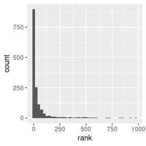

```r
if (require(ggplot2)) {
        evaluation %>%
                filter(correct, true != "<EOS>") %>%
                select(true) %>%
                transmute(rank = match(true, table = attr(p, "dict"))) %>%
                ggplot(aes(x = rank)) + geom_histogram(binwidth = 25)
}
```

Apparently, the large majority of correct predictions come from the first ~ 300 words of the dictionary, so that if we prune the dictionary excluding words with rank greater than, *e.g.*, 500 we can reduce the size of our model without seriously affecting its prediction accuracy.

## Other functionalities

In this Section, I briefly survey other functionalities provided by `sbo`. See the corresponding help pages for more details.

### Dictionaries

Dictionaries can be directly built using `sbo_dictionary()`. For example, the command:

```r
dict <- sbo_dictionary(corpus = sbo::twitter_train,
                       max_size = 100,
                       target = 0.5,
                       .preprocess = sbo::preprocess,
                       EOS = ".?!:;")
```

constructs a dictionary applying the most restrictive of the two constraint `max_size = 100` or `target = 0.5`, where `target` denotes the coverage fraction of `corpus`. The arguments `.preprocess` and `EOS` work as described above.

The output is an object of class `sbo_dictionary`, which stores, along with a vector of words (sorted by decreasing frequency), also the original values of `.preprocess` and `EOS`.

### Word coverage

The word coverage fraction of a dictionary can be computed through the generic function `word_coverage()`. This accepts as argument any object containing a dictionary, along with a preprocessing function and a list of End-Of-Sentence characters. This includes all `sbo` main classes: `sbo_dictionary`, `sbo_kgram_freqs`, `sbo_predtable` and `sbo_predictor`. For instance:

```r
(c <- word_coverage(p, sbo::twitter_train))
```

```
#> A 'word_coverage' object.
#>
#> See summary() for more details.
```

Computes the coverage fraction of the dictionary used by the predictor `p`, on the original training corpus.

This can be conveniently summarized with:

```r
summary(c)
```

```
#> Word coverage fraction
#>
#> Dictionary length: 1008
#> Coverage fraction (w/ EOS): 78.2 %
#> Coverage fraction (w/o EOS): 75 %
```

or visualized with:

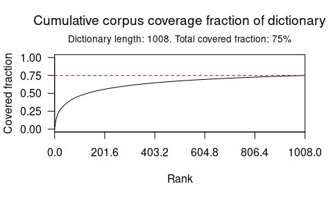

```r
plot(c)
```

### $k$-gram tokenization

$k$-gram frequency tables form the building blocks of *any* $N$-gram based language model. The function `sbo::kgram_freqs()` extracts frequency tables from a training corpus and stores them into a class `sbo_kgram_freq` object. For example:

```r
f <- kgram_freqs(corpus = sbo::twitter_train,
                 N = 3,
                 dict = target ~ 0.75,
                 .preprocess = sbo::preprocess,
                 EOS = ".?!:;"
                 )
```

stores $k$-gram frequency tables into `f`. This object can itself be used for text prediction:

```r
predict(f, "i love")
```

```
#> # A tibble: 1,009 x 2
#>    completion probability
#>    <chr>            <dbl>
#>  1 you             0.222
#>  2 it              0.0573
#>  3 my              0.0549
#>  4 the             0.0524
#>  5 your            0.0312
#>  6 this            0.0312
#>  7 that            0.0287
#>  8 how             0.0249
#>  9 u               0.0175
#> 10 when            0.0150
#> # … with 999 more rows
```

The output contains the full language model information, i.e. the probabilities[[^5]](https://cran.r-project.org/web/packages/sbo/vignettes/sbo.html#fn5) for each possible word completion. Compare this with:

```r
predict(p, "i love")
```

```
#> [1] "you" "it"  "my"
```

The extra information contained in `f` comes at a price. In fact, the advantage provided by `sbo_predictor`/`sbo_predtable` objects for simple text prediction is two-fold:

1. Memory compression:

```r
size_in_MB <- function(x) format(utils::object.size(x), units = "MB")
sapply(list(sbo_predtable = t, kgram_freqs = f), size_in_MB)
```

```
#> sbo_predtable   kgram_freqs
#>      "1.4 Mb"      "4.7 Mb"
```

2. Fast query:

```r
chrono_predict <- function(x) system.time(predict(x, "i love"), gcFirst = TRUE)
lapply(list(sbo_predictor = p, kgram_freqs = f), chrono_predict)
```

```
#> $sbo_predictor
#>    user  system elapsed
#>   0.001   0.000   0.001
#>
#> $kgram_freqs
#>    user  system elapsed
#>   0.141   0.000   0.142
```

### Text preprocessing

Usually text corpora require preprocessing before word and $k$-gram tokenization can take place. The `.preprocess` argument of `kgram_freqs()` allows for an user specified preprocessing function. The default is the minimal `sbo::preprocess()`, and the optimized `kgram_freqs_fast(erase = x, EOS = y)` is equivalent to `kgram_freqs(.preprocess = sbo::preprocess(erase = x, EOS = y))` (but more efficient).

### Sentence tokenization

Tokenization at the sentence level is required to obtain terminal $k$-grams (i.e. $k$-grams containing Begin-Of-Sentence or End-Of-Sentence tokens). In the training process, sentence tokenization takes place after text preprocessing.

End-Of-Sentence (single character) tokens are specified by the `EOS` argument of `kgram_freqs()` and `kgram_freqs_fast()`; empty sentences are always skipped. Also, if the input vector `text` has `length(text) > 1`, the various elements of `text` belong to different entries.

The process of sentence tokenization can also be performed directly, through `sbo::tokenize_sentences()`, but this is not required for use with `kgram_freqs*()`.

[^1]: This is a small samples of $5·10^4$ entries from the “Tweets” Swiftkey dataset fully available [here](https://www.kaggle.com/crmercado/tweets-blogs-news-swiftkey-dataset-4million).
[^2]: At the present stage of development, this cannot be done directly for the `sbo_predictor` object created above. Technically, this is because `sbo_predictor` objects are external pointers to a convenient C++ class, optimized for fast `predict()`ions. Such a class instance exists only during a single R session.
[^3]: As this example makes clear, both `sbo_predictor()` and `sbo_predtable()` are S3 generics. The corresponding available methods are listed under `?sbo_predictions`.
[^4]: Coded with respect to the rank sorted dictionary `dict` (the codes `0`, `length(dict) + 1` and `length(dict) + 2` correspond to the Begin-Of-Sentence, End-Of-Sentence and Unknown-Word tokens, respectively).
[^5]: More precisely, these are the normalized (to unity) scores resulting from the Stupid Back-Off smoothing method.